# Siklus Hidup Analisis Data (Data Analytics Lifecycle)

Weksi Budiaji

2025-09-04

### **Pendahuluan**

Proyek sain data memiliki karakter yang berbeda dari proyek Business Intelligence (BI) tradisional dan banyak proyek analisis data lainnya karena sifatnya yang lebih eksploratif. Untuk alasan ini, sangat penting untuk memiliki sebuah proses yang mengatur pelaksanaannya untuk memastikan bahwa analis bersikap teliti dalam pendekatan mereka, namun tidak terlalu kaku sehingga justru menghambat eksplorasi yang diperlukan.

Banyak masalah yang awalnya tampak besar dan menakutkan dapat dipecah menjadi bagian-bagian yang lebih kecil atau fase-fase yang dapat ditindaklanjuti (*actionable*) untuk lebih mudah ditangani secara komprehensif dan dapat diulang dalam hal analisis. Selain itu, proses ini memfokuskan waktu dan energi di awal untuk memahami masalah bisnis yang harus dipecahkan.

Kesalahan umum dalam sains data adalah terburu-buru langsung ke tahap pengumpulan dan analisis data, yang mengakibatkan tidak cukupnya waktu untuk merencanakan dan mengukur cakupan pekerjaan, memahami kebutuhan, atau bahkan mendefinisikan masalah bisnis dengan tepat. Akibatnya, di tengah jalan, baru disadari bahwa yang diinginkan oleh penyandang dana (*project sponsor*) mungkin tidak sesuai dengan data yang tersedia, atau teridentifikasi kepentingan yang berbeda dari yang telah dikomunikasikan diawal. Jika hal ini terjadi, proyek mungkin harus kembali ke fase awal untuk melakukan fase penemuan (*discovery*) yang sesuai, atau bahkan dibatalkan.

Proses yang diciptakan dan didokumetasikan membantu dan memberikan kredibilitas tambahan pada proyek ketika tim data sains membagikan temuannya. Proses yang terdefinisi dengan baik juga menawarkan kerangka kerja bersama untuk diadopsi oleh orang lain, sehingga metode dan analisis dapat diulang di masa depan atau ketika anggota baru bergabung ke dalam tim.

#### **2.1 Gambaran Umum Siklus Hidup Analisis Data (Data Analytics Lifecycle)**

Siklus Hidup Analisis Data dirancang khusus untuk menangani masalah Big Data dan proyek sains data. Siklus ini terdiri atas enam fase, dan beberapa pekerjaan dapat terjadi dalam beberapa fase yang bersamaan. Sebagian fase dalam siklus, pergerakannya dapat maju atau mundur. Penggambaran iteratif dari siklus hidup ini dimaksudkan untuk lebih mendekati gambaran proyek nyata, di mana aspek-aspek proyek bergerak maju dan mungkin kembali ke tahap sebelumnya ketika informasi baru ditemukan dan anggota tim mempelajari lebih lanjut berbagai tahapan proyek. Ini memungkinkan pergerakan tahap secara iteratif melalui proses dan mendorong menuju operasionalisasi proyek.

**2.1.1 Peran Kunci untuk Kesuksesan Proyek Analitik**

Meskipun banyak perhatian diberikan pada peran emerging “Data Scientist”, sebenarnya ada tujuh peran kunci yang perlu dipenuhi agar tim data sains dapat berfungsi dengan baik dan menjalankan proyek analitik dengan sukses.

1. **Pengguna (Business User):** Seseorang yang memahami domain area dan biasanya mendapat manfaat dari hasilnya. Peran ini memberikan masukan tentang konteks proyek, nilai hasil, dan bagaimana output akan dioperasionalkan.
2. **Penyandang Dana Proyek (Project Sponsor):** Bertanggung jawab atas dimulainya proyek. Menyediakan dorongan, dana, persyaratan, dan mendefinisikan inti masalah bisnis.
3. **Manajer Proyek (Project Manager):** Memastikan bahwa milestone dan tujuan kunci terpenuhi tepat waktu dan dengan kualitas yang diharapkan.
4. **Analis Business Intelligence (BI Analyst):** Memberikan keahlian domain bisnis berdasarkan pemahaman mendalam tentang data, KPI (*Key Performance Indicator*), metrik, dan pelaporan. Biasanya membuat dashboard dan laporan.
5. **Administrator Basis Data (Database Administrator - DBA):** Menyediakan dan mengkonfigurasi lingkungan basis data untuk mendukung kebutuhan analitik tim.
6. **Data Engineer:** Memiliki keterampilan teknis yang mendalam SQL, manajemen data, ekstraksi data, dan mendukung input data ke dalam lingkungan data analitik. Bekerja erat dengan data scientist untuk membentuk data agar siap dianalisis.
7. **Ilmuwan Data (Data Scientist):** Memberikan keahlian dalam teknik analitik, pemodelan data, dan menerapkan teknik analitik yang valid untuk masalah bisnis yang dihadapi. Merancang dan mengeksekusi metode analitik.

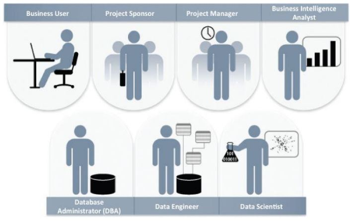

Peran kunci tim data sains

Pada tim yang kecil, ketujuh peran ini mungkin hanya beranggotakan 3 orang, tetapi proyek yang sangat besar mungkin membutuhkan 20 orang atau lebih.

**2.1.2 Latar Belakang dan Tinjauan Siklus Hidup Analisis Data**

Siklus Hidup Analisis Data didefinisikan sebagai praktik terbaik dalam proses analitik yang mencakup penemuan hingga penyelesaian proyek. Siklus ini mengambil dari metode-metode yang telah ada di ranah analitik data dan ilmu keputusan (*decision science*), seperti:

- **Metode Ilmiah (Scientific Method):** Memberikan kerangka kerja solid untuk memecahkan masalah menjadi bagian-bagian utama, termasuk membentuk hipotesis dan mengujinya.
- **CRISP-DM (Cross-Industry Standard Process for Data Mining):** Memberikan masukan tentang cara membingkai masalah analitik dan merupakan pendekatan populer untuk data mining.
- **Kerangka DELTA Tom Davenport:** Menawarkan pendekatan untuk proyek analitik data, termasuk konteks keterampilan organisasi, dataset, dan keterlibatan kepemimpinan.
- **Pendekatan Applied Information Economics (AIE) Doug Hubbard:** Memberikan kerangka kerja untuk mengukur hal-hal tidak berwujud dan panduan untuk mengembangkan model keputusan.
- **“MAD Skills” oleh Cohen et al.:** Memberikan masukan untuk beberapa teknik dalam fase perencanaan, eksekusi, dan temuan model.

Siklus ini terdiri dari enam fase yang bersifat iteratif, di mana tim dapat kembali ke fase sebelumnya berdasarkan wawasan baru yang ditemukan.

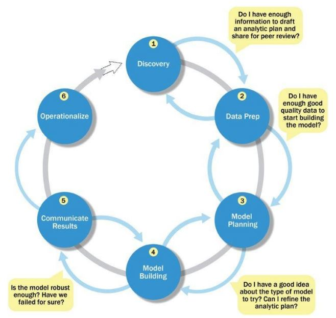

Siklus hidup analisis data

#### **2.2 Fase 1: Penemuan (Discovery)**

Pada fase pertama ini, tim mempelajari domain bisnis yang relevan, termasuk sejarah apakah organisasi pernah mencoba proyek serupa sebelumnya. Tim menilai sumber daya yang tersedia untuk mendukung proyek, baik berupa orang, teknologi, waktu, maupun data.

**Aktivitas Penting:**

- **Memahami Masalah Bisnis:** Mendefinisikan masalah bisnis dengan jelas dan membingkainya kembali sebagai tantangan analitik. Pemahaman yang mendalam tentang domain atau area bisnis dari masalah yang dihadapi adalah hal yang esensial. Keahlian seorang ilmuwan data dapat dibagi menjadi dua jenis: (1) **Ahli Kuantitatif**: Memiliki pengetahuan komputasi dan kuantitatif yang dalam (misalnya, latar belakang matematika terapan atau statistik) yang dapat diterapkan secara luas di berbagai disiplin ilmu. Keahlian mereka terletak pada metode, teknik, dan cara menerapkan heuristik untuk berbagai masalah bisnis dan konseptual. (2) **Ahli Domain**: Memiliki pengetahuan yang mendalam tentang suatu bidang studi tertentu (misalnya, life science, oceanography, genetika) yang dipadukan dengan keahlian kuantitatif.Di awal proyek, tim perlu menilai seberapa banyak pengetahuan domain yang harus dikuasai oleh ilmuwan data untuk mengembangkan model di fase-fase selanjutnya. Penilaian ini penting untuk memastikan tim memiliki keseimbangan yang tepat antara keahlian domain dan keahlian teknis.
- **Formulasi Hipotesis Awal (Initial Hypotheses - IHs):** Mengajukan dugaan awal yang dapat diuji dengan data untuk menjawab tantangan bisnis. Mengembangkan seperangkat Hipotesis Awal (IHs) adalah aspek kunci dari fase penemuan. Hipotesis adalah ide atau dugaan yang dapat diuji dengan data. Langkah-langkahnya dapat berupa (1) Merumuskan Hipotesis Utama: Buat beberapa hipotesis utama yang akan diuji.(2) Brainstorming: Kembangkan hipotesis tambahan yang lebih kreatif.(3) Melibatkan Stakeholder: Kumpulkan dan nilai hipotesis dari stakeholder dan ahli domain. Mereka sering kali memiliki perspektif berharga tentang masalah dan solusi potensial.(4) Eksplorasi Data Awal: Jika memungkinkan, eksplorasi data awal dapat menginformasikan dan mempertajam hipotesis yang dirumuskan. IHs ini akan menjadi dasar untuk pengujian analitik di fase selanjutnya dan fondasi untuk temuan yang akan dikomunikasikan di Fase 5.
- **Identifikasi Sumber Data:** Mengidentifikasi data yang diperlukan, sumbernya, dan bagaimana cara mengaksesnya. Hal penting yang harus dilakukan antara lain (1) Identifikasi Sumber Data: Buat daftar sumber data kandidat (internal dan eksternal).(2) Data Agregat: Gunakan data agregat untuk mendapatkan gambaran umum dan pemahaman tingkat tinggi tentang data yang ada. (3) Data Mentah (Raw Data): Akses dan tinjau data mentah untuk memahami interdependensi antar atribut, kualitas data, dan keterbatasannya. Data mentah umumnya lebih disukai untuk menghindari bias dalam analisis. (4) Evaluasi Struktur dan Alat: Struktur dan jenis data akan memengaruhi alat dan teknologi yang dapat digunakan (misalnya, Hadoop untuk data tidak terstruktur dalam skala besar, atau SQL untuk data terstruktur). (5) Cakupan Infrastruktur: Perkirakan kebutuhan infrastruktur yang diperlukan (seperti penyimpanan disk dan kapasitas jaringan) berdasarkan volume dan karakteristik data.
- **Menilai Sumber Daya dan Keterbatasan:** Mengevaluasi kecukupan alat, infrastruktur, dan keahlian yang dimiliki. (1) Teknologi dan Alat: Pertimbangkan alat dan teknologi yang akan digunakan, serta sistem yang diperlukan untuk mengoperasionalkan model di fase akhir. (2) Tingkat Kematangan Analitik Organisasi: Evaluasi kesiapan organisasi dari segi alat (tools), teknologi, dan keterampilan. Pertimbangkan juga keterampilan seperti apa yang dibutuhkan untuk memelihara model dalam jangka panjang. (3) Data: Lakukan inventarisasi terhadap jenis data yang tersedia. Pertanyakan apakah data yang ada cukup untuk mendukung tujuan proyek. Tim harus menentukan apakah perlu mengumpulkan data tambahan, membelinya dari sumber eksternal, atau mentransformasi data yang sudah ada.

Fase ini adalah dasar dari seluruh proyek. Kegagalan di fase ini sering menyebabkan salah arah dan kegagalan proyek.

Kapan Beralih ke Fase Selanjutnya?

Tidak seperti proses tradisional yang kaku, perpindahan antar fase dalam Siklus Hidup Analisis Data bersifat iteratif dan luwes. Tim dapat beralih ke Fase 2: Persiapan Data ketika mereka **telah memperoleh informasi yang cukup untuk membuat Rencana Analitik (Analytics Plan)** yang draft-nya dapat dibagikan untuk ditinjau sejawat (peer review). Membuat rencana analitik ini adalah ujian yang baik untuk memastikan tim telah memahami masalah bisnis, pendekatan yang akan diambil, sumber data yang akan digunakan, dan kriteria kesuksesan yang telah disepakati.

#### **2.3 Fase 2: Persiapan Data (Data Preparation)**

Fase kedua dari Siklus Hidup Analisis Data adalah Persiapan Data. Fase ini mencakup langkah-langkah untuk mengeksplorasi, memproses awal (preprocess), dan mengkondisikan data sebelum pemodelan dan analisis. Pada fase ini, tim perlu menciptakan lingkungan yang robust untuk menjelajahi data, yang terpisah dari lingkungan produksi. Lingkungan ini biasanya disebut *Analytic Sandbox* (Kotak Pasir Analitik).

Fase persiapan data cenderung menjadi langkah yang paling memakan waktu dan tenaga dalam seluruh siklus analitik. Faktanya, adalah hal yang umum bagi tim untuk menghabiskan setidaknya 50% dari total waktu proyek sains data pada fase kritis ini. Mengabaikan fase ini dan terburu-buru masuk ke pemodelan hampir selalu berakibat pada kembalinya tim ke fase ini untuk memperbaiki data, sehingga justru menghabiskan lebih banyak waktu.

Langkah pertama dalam persiapan data adalah memperoleh sebuah Analytic Sandbox (atau workspace). Sandbox adalah lingkungan di mana tim dapat bereksperimen dan menjelajahi data tanpa takut mengganggu kinerja atau keamanan basis data produksi yang live.

- **Filosofi**: Sandbox harus berisi semua jenis data yang mungkin dibutuhkan, mulai dari data agregat, data terstruktur, raw data feeds, hingga data tidak terstruktur seperti log panggilan atau log web. Pendekatan “semua data boleh masuk” ini sangat berbeda dengan pendekatan tradisional TI yang biasanya hanya memberikan akses ke data spesifik untuk tujuan spesifik.
- **Kolaborasi dengan TI** : Perbedaan filosofi ini sering kali menimbulkan gesekan antara tim sains data yang menginginkan akses seluas-luasnya dan tim TI yang bertugas menjaga keamanan dan stabilitas. Oleh karena itu, kolaborasi dan komunikasi yang baik sangat penting. Tim sains data perlu memberikan justifikasi yang jelas tentang pentingnya sandbox untuk proyek analitik yang lebih ambisius.
- **Ukuran**: Sandbox harus dipersiapkan dengan kapasitas yang besar, biasanya 5-10 kali lebih besar dari ukuran dataset asli. Hal ini karena tim mungkin perlu membuat banyak salinan data dalam bentuk yang berbeda untuk berbagai jenis analisis.

**Aktivitas Penting:**

- **Ekstraksi, Transformasi, Load (ETL/ELT):** Tim perlu mengekstrak data dari berbagai sumber, mentransformasikannya (membersihkan, mengagregasi, memformat), dan memuatnya ke dalam sandbox (ETL). Data diekstrak dalam bentuk raw (mentah) dan langsung dimuat ke dalam sandbox (ELT). Transformasi dilakukan setelah data berada di sandbox. Pendekatan ini lebih disukai dalam sains data karena menjaga data asli tetap utuh, memungkinkan tim untuk mengaksesnya guna menemukan pola tersembunyi yang mungkin hilang jika data sudah dibersihkan terlebih dahulu.
- **Eksplorasi dan Pemahaman Data:** Tim harus benar-benar mengenal data dengan melakukan analisis eksploratori (Exploratory Data Analysis - EDA) untuk memahami distribusi, korelasi, anomali, dan karakteristik data lainnya. Hal penting yang dilakukan (1) Mengkatalogkan Sumber Data: Membuat inventaris data yang dapat diakses dan mengidentifikasi data tambahan yang berguna tetapi belum dapat diakses. (2) Mengidentifikasi Kesenjangan: Menyoroti dataset yang berguna tetapi tidak dapat diakses, sehingga memicu inisiatif untuk menjalin hubungan dengan pemilik data atau mulai mengumpulkan data baru. (3) Mencari Data Eksternal: Mengidentifikasi dataset di luar organisasi yang dapat diperoleh melalui API terbuka, berbagi data, atau pembelian.
- **Kondisioning Data:** Melakukan pembersihan data (*handling missing values, outliers*), transformasi (normalisasi, standardisasi), dan *enrichment data* jika diperlukan untuk membuat data siap untuk pemodelan. Penting untuk melibatkan data scientist dalam langkah ini, bukan hanya insinyur data atau DBA, karena banyak keputusan dalam kondisioning data akan memengaruhi analisis. Membuang data yang salah dapat berakibat fatal dan memaksa tim untuk mengulangi proses dari awal.

Kualitas output fase ini sangat menentukan keberhasilan fase pemodelan. Data yang buruk akan menghasilkan model yang buruk (*Garbage In, Garbage Out*).

Kapan Beralih ke Fase Selanjutnya?

Tim dapat beralih ke Fase 3: Perencanaan Model ketika mereka telah:

1. Berhasil memuat data yang diperlukan ke dalam analytic sandbox.
2. Memahami karakteristik, kualitas, dan keterbatasan data dengan cukup baik.
3. Melakukan kondisioning data sehingga data berada dalam format yang dapat dimasukkan ke dalam algoritma pemodelan.
4. Melakukan eksplorasi awal melalui visualisasi yang memvalidasi atau mempertanyakan hipotesis awal, sehingga memberikan arah yang jelas untuk jenis pemodelan seperti apa yang akan dilakukan selanjutnya.

#### **2.4 Fase 3: Perencanaan Model (Model Planning)**

Pada fase ini, tim menentukan metode, teknik, dan alur kerja (*workflow*) yang akan diikuti untuk fase pembangunan model. Fase ini adalah tentang merencanakan *bagaimana* model akan dibangun. Tim data sains mengidentifikasi model-model kandidat yang akan diterapkan pada data untuk melakukan clustering, classification, atau menemukan hubungan dalam data, tergantung pada tujuan proyek.

Pada fase inilah tim merujuk kembali kepada hipotesis awal (IHs) yang dikembangkan di Fase 1. Hipotesis-hipotesis ini membantu tim membingkai analitik seperti apa yang akan dieksekusi di Fase 4 dan memilih metode yang tepat untuk mencapai tujuannya.

Fase perencanaan model adalah jembatan antara pemahaman data dan pembangunan model. Jika fase ini dilewati maka dapat menyebabkan pemilihan model yang tidak sesuai, yang berujung pada hasil yang tidak akurat atau tidak dapat diinterpretasikan.

**Aktivitas Penting:**

- **Seleksi Teknik dan Algoritma:** Memilih teknik analitik yang sesuai (seperti klasifikasi, regresi, clustering) dan algoritma spesifik (seperti Random Forest, Regression, K-Means) berdasarkan masalah dan karakteristik data. Hal yang perlu diperhatikan: (1) Pertimbangkan Sifat Data: Apakah data terstruktur, tidak terstruktur, atau hibrid? Teknik untuk menganalisis teks (seperti Natural Language Processing) akan berbeda dengan teknik untuk menganalisis data transaksi terstruktur. (2) Penelitian dan Benchmarking: Sangat berguna untuk meneliti bagaimana analis lain umumnya mendekati masalah serupa. (3) Membuat Daftar Pendek (Shortlist) Kandidat: Daripada memilih satu model, sering kali lebih baik membuat daftar pendek (2-3) model kandidat yang memiliki peluang terbaik untuk berhasil. Daftar ini akan diuji dan dibandingkan di Fase 4. (4) Mendokumentasikan Asumsi: Sangat penting untuk mengidentifikasi dan mendokumentasikan semua asumsi yang mendasari pemilihan model. Asumsi ini akan menjadi kriteria evaluasi nantinya. (5) Mempertimbangkan Skalabilitas: Model awal sering dibuat dengan paket statistik seperti R atau Python (scikit-learn) pada sampel data. Tim harus mempertimbangkan apakah model ini akan dapat diskalakan (scalable) untuk berjalan pada keseluruhan dataset yang sangat besar (Big Data) di lingkungan produksi. Teknologi seperti in-database analytics (misalnya, menggunakan SQL Advanced Analytics) atau framework seperti Spark MLlib mungkin perlu dipertimbangkan untuk skalabilitas
- **Perancangan Eksperimen:** Merancang cara untuk menguji hipotesis dan mengevaluasi model. Untuk masalah yang kompleks, solusinya mungkin membutuhkan lebih dari satu model. Tim perlu merancang alur kerja analitik (analytic workflow) yang merupakan serangkaian langkah terurut. Alur kerja ini harus didokumentasikan dengan jelas, biasanya dalam bentuk diagram, sebelum masuk ke Fase 4.
- **Pembagian Data:** Merencanakan pembagian dataset menjadi data untuk pelatihan (*training*), pengujian (*testing*), dan validasi (*validation*).
- **Penentuan Metrik Evaluasi:** Memilih metrik yang tepat (seperti Akurasi, Presisi, Recall, RMSE, AUC-ROC) untuk mengukur kinerja model.

Beberapa alat yang umum digunakan untuk perencanaan model: (1) **R**: Bahasa pemrograman open source yang sangat powerful untuk komputasi statistik dan grafik. R memiliki ribuan package (seperti caret, randomForest, ggplot2) yang mencakup hampir semua teknik pemodelan yang dapat dibayangkan. Sangat cocok untuk prototyping dan pengembangan model interpretatif. (2) **Python (dengan library Scikit-learn, Pandas, Matplotlib)**: Merupakan pesaing utama R. Python menawarkan ekosistem yang sangat kuat untuk sains data, dengan library yang user-friendly dan kemampuan pemrograman umum yang lebih baik untuk mengintegrasikan model ke dalam produk aplikasi. (3) **SQL Analysis Services**: Untuk organisasi yang berinvestasi banyak pada Microsoft, tools ini memungkinkan untuk melakukan analitik dan data mining dasar langsung di dalam database. (4) **SAS/ACCESS**: Menyediakan integrasi antara SAS (sebuah platform analitik komersial yang sangat mapan) dan berbagai sumber data seperti database relasional dan data warehouse.

Fase ini memastikan bahwa pendekatan yang diambil terstruktur dan didasarkan pada pertimbangan yang matang sebelum menghabiskan sumber daya untuk membangun model.

Kapan Beralih ke Fase Selanjutnya?

Tim dapat beralih ke Fase 4: Pembangunan Model ketika mereka telah:

1. Memilih Daftar Pendek Model Kandidat: Telah mengidentifikasi satu atau beberapa teknik analitik yang akan diuji.
2. Memahami Variabel dengan Baik: Memiliki pemahaman yang kuat tentang variabel prediktor dan target yang akan digunakan.
3. Memiliki Rencana yang Jelas: Memiliki metodologi umum untuk model analitik dan deskripsi/diagram alur kerja yang akan diikuti.
4. Menyiapkan Data untuk Pemodelan: Data telah diproses, dipilih, dan diformat sedemikian rupa sehingga siap untuk diumpankan (feed) ke dalam algoritma pemodelan yang dipilih.

#### **2.5 Fase 4: Pembangunan Model (Model Building)**

Dalam fase ini, tim mengembangkan dataset untuk keperluan pengujian, pelatihan, dan produksi. Pada fase ini, tim sains data mewujudkan rencana yang telah dibuat di fase sebelumnya dengan membangun, melatih, dan menguji model-model kandidat.

**Aktivitas Penting:**

- **Pembangunan Model:** Melatih model menggunakan algoritma yang dipilih pada data training. Dataset ini biasanya dibagi menjadi dua bagian: (1) Data Latih (Training Data): Dataset yang digunakan untuk “mengajar” atau melatih model. Algoritma mempelajari pola dan hubungan dalam data ini. (2) Data Uji (Test Data/Hold-out Data): Dataset yang tidak pernah dilihat oleh model selama pelatihan. Dataset ini digunakan untuk menguji seberapa baik model yang telah dilatih dapat melakukan generalisasi pada data baru yang belum pernah dilihat. Ini adalah simulasi dari bagaimana model akan performa di dunia nyata.
- **Pengujian dan Validasi Model:** Menguji model pada data testing yang belum pernah dilihat sebelumnya untuk menilai kinerja dan generalisasinya.
- **Penyetelan Model (Model Tuning):** Menyesuaikan hyperparameter model untuk meningkatkan kinerjanya. Dataset yang digunakan untuk menyesuaikan hyperparameters model dan memilih model terbaik selama proses pengembangan. Ini membantu mencegah overfitting pada data uji.Dataset yang digunakan adalah data validasi (Opsional, tetapi sangat disarankan)
- **Evaluasi terhadap Metrik:** Mengukur kinerja model menggunakan metrik yang telah ditentukan di fase 3. Model yang telah dilatih dan disetel harus dievaluasi secara ketat terhadap data uji. Evaluasi ini menggunakan metrik yang telah disepakati di Fase 1, yang sesuai dengan tujuan bisnis. Untuk Klasifikasi menggunakan Akurasi, Presisi, Recall, F1-Score, AUC-ROC sedangkan untuk Regresi berupa Mean Absolute Error (MAE), Mean Squared Error (MSE), R-squared. Selain metrik numerik, sangat penting untuk mempresentasikan perilaku model kepada **ahli domain**. Apakah output model **masuk akal** secara bisnis? Sebuah model mungkin memiliki akurasi tinggi tetapi membuat prediksi yang tidak logis dalam konteks domainnya, yang menandakan ada sesuatu yang salah (misalnya, kebocoran data / data leakage).
- **Pertimbangan Infrastruktur:** Menilai apakah alat dan lingkungan komputasi saat ini cukup untuk menjalankan model, atau jika diperlukan lingkungan yang lebih robust (seperti hardware yang lebih cepat dan pemrosesan paralel computing).

Fase ini bersifat sangat iteratif, sering kali mengharuskan tim kembali ke fase perencanaan model untuk menyesuaikan pendekatan berdasarkan hasil yang diperoleh. Keputusan-keputusan kecil tentang data dan pendekatan pemodelan juga sering dibuat sehingga sangat penting untuk mendokumentasikan semua hal ini: asumsi yang dibuat, parameter yang dipilih, hasil setiap eksperimen, dan logika di balik setiap keputusan. Dokumentasi ini penting untuk reproduktibilitas, audit, dan pengembangan model di masa depan.

Kapan Beralih ke Fase Selanjutnya?

Tim dapat beralih ke Fase 5: Komunikasi Hasil ketika mereka telah:

1. Memiliki Model Final: Telah memilih satu model (atau ensemble model) yang paling baik memenuhi kriteria kesuksesan.
2. Mengetahui Kinerja Model: Telah mengevaluasi model secara menyeluruh pada data uji dan memahami kekuatan serta kelemahannya.
3. Siap Bercerita: Memiliki semua hasil dan wawasan yang perlu dikomunikasikan kepada stakeholder.

#### **2.6 Fase 5: Komunikasi Hasil (Communicate Results)**

Fase kelima dari Siklus Hidup Analisis Data adalah Komunikasi Hasil. Setelah model dieksekusi, tim perlu membandingkan hasil pemodelan dengan kriteria kesuksesan dan kegagalan yang telah ditetapkan di Fase 1. Pada fase ini, tim mempertimbangkan cara terbaik untuk mengartikulasikan temuan dan hasil kepada berbagai anggota tim dan pemangku kepentingan, dengan mempertimbangkan peringatan, asumsi, dan segala batasan dari hasil yang diperoleh.

Sebagai bagian dari Fase 5, tim perlu menentukan apakah mereka berhasil atau gagal dalam mencapai tujuan. Penting untuk dipahami bahwa dalam konteks sains data, “kegagalan” tidak selalu berarti kegagalan yang sebenarnya. Sering kali, ini adalah kegagalan data untuk menerima atau menolak hipotesis yang diberikan dengan memadai.

**Aktivitas Penting:**

- **Identifikasi Temuan Kunci:** Menyimpulkan insight utama yang dihasilkan dari analisis. Bandingkan hasil aktual dengan ide-ide yang dirumuskan sejak dini (di Fase 1). Ini menghasilkan ide dan wawasan tambahan yang mungkin terlewatkan jika tim tidak meluangkan waktu untuk merumuskan hipotesis awal. Praktik terbaik dalam fase ini adalah mencatat semua temuan dan kemudian memilih tiga yang paling signifikan untuk dibagikan dengan para pemangku kepentingan. Terlalu banyak informasi dapat mengaburkan pesan utama.
- **Kuantifikasi Nilai Bisnis:** Menerjemahkan hasil teknis menjadi dampak bisnis yang terukur (seperti peningkatan pendapatan, pengurangan biaya, peningkatan efisiensi). Tim perlu merefleksikan implikasi dari temuan-temuan ini dan mengukur nilai bisnisnya. Bergantung pada hasil model, tim mungkin perlu meluangkan waktu untuk mengkuantifikasi dampak bisnis dari hasil tersebut. Ini membantu mempersiapkan presentasi dan menunjukkan nilai dari temuan yang didapat, bahkan untuk hal-hal yang tampaknya tidak terukur (*intangibles*).
- **Pengembangan Narasi:** Membuat cerita yang menarik menjelaskan masalah, pendekatan, temuan, dan rekomendasi secara logis dan mudah diikuti. Hal ini diperlukan untuk menyampaikan temuan kepada audiens dengan latar belakang yang berbeda-beda (teknis dan non-teknis) dengan menghindari jargon yang tidak perlu. Penggunaan grafik, chart, dan dashboard yang efektif dan bahasa yang mudah dipahami untuk menyampaikan pesan dengan cepat dan jelas. Prinsip “Overview first, zoom and filter, then details-on-demand” sangat berlaku.
- **Rekomendasi:** Memberikan rekomendasi tindakan yang dapat diambil berdasarkan temuan. Rekomendasi ini adalah rekomendasi yang spesifik dan dapat ditindaklanjuti, yang mengarah pada Fase 6 (Operationalize).

Komunikasi yang efektif adalah kunci. Analisis yang secara teknis akurat tetapi gagal disampaikan dengan baik akan kehilangan nilainya.

#### **2.7 Fase 6: Operationalize**

Dalam fase terakhir ini, tim mengirimkan laporan akhir, briefings, kode, dan dokumen teknis. Intinya adalah menerapkan hasil kerja model ke dalam lingkungan operasional untuk memberikan nilai nyata.

**Aktivitas Penting:**

- **Pilot Project:** Menjalankan proyek percontohan untuk menerapkan model dalam lingkungan produksi yang terkendali untuk menguji efektivitas dan dampaknya. Pendekatan pilot project memungkinkan tim untuk mempelajari kinerja dan kendala terkait model dalam lingkungan produksi pada skala kecil dan melakukan penyesuaian sebelum aplikasi penuh.Saat menentukan cakupan pilot project, pertimbangkan untuk menjalankan model dalam lingkungan produksi untuk seperangkat produk tertentu atau satu lini bisnis tunggal. Ini menguji model dalam pengaturan yang live namun terisolasi.
- **Pembuatan Laporan dan Dokumentasi Akhir:** Memastikan semua cetak biru proyek terdokumentasi dengan baik untuk keperluan reproduksi dan pemeliharaan di masa depan.
- **Pemantauan Kinerja Model:** Merencanakan bagaimana model akan dipantau kinerjanya secara berkelanjutan di dunia nyata, karena model dapat menjadi usang seiring waktu (konsep “model drift”). Bagian kritis dari fase operasionalisasi adalah menciptakan mekanisme untuk melakukan pemantauan berkelanjutan (ongoing monitoring) terhadap akurasi model. Hal yang penting adalah (1) Model Retraining: Jika akurasi model menurun (model decay atau concept drift), tim harus menemukan cara untuk melatih ulang (retrain) model dengan data yang lebih baru. Performa model dapat menurun seiring waktu karena perubahan perilaku pelanggan, kondisi pasar, atau faktor eksternal lainnya. (2) Peringatan “Out-of-Bounds”: Jika memungkinkan, rancang sistem peringatan (alerts) untuk ketika model beroperasi di luar batas yang ditentukan. Ini termasuk situasi di mana input data berada di luar jangkauan yang digunakan untuk melatih model, yang dapat menyebabkan output menjadi tidak akurat atau tidak valid.
- **Penyerahan ke Tim Operasional:** Menyerahkan model dan proses yang telah terbukti berhasil kepada tim operasional untuk dijalankan secara rutin (integrasi).

Kunci Sukses Operasionalisasi

1. Komunikasi yang Berkelanjutan: Fase ini membutuhkan kolaborasi erat antara tim data science dan tim operasional/IT.
2. Dokumentasi yang Matang: Kode dan proses harus terdokumentasi dengan sangat baik untuk memastikan keberlanjutan dan kemudahan pemeliharaan.
3. Manajemen Perubahan: Memastikan bahwa pengguna akhir (seperti tim pemasaran atau operasional) memahami bagaimana menggunakan output model dalam workflow mereka sehari-hari. 4.Pemikiran Jangka Panjang: Perencanaan untuk pemantauan, pemeliharaan, dan pengembangan model lebih lanjut setelah proyek selesai.

Fase ini memastikan bahwa investasi dalam proyek sains data tidak berakhir sebagai sekadar eksperimen atau laporan, tetapi benar-benar diintegrasikan ke dalam proses bisnis.

### contoh

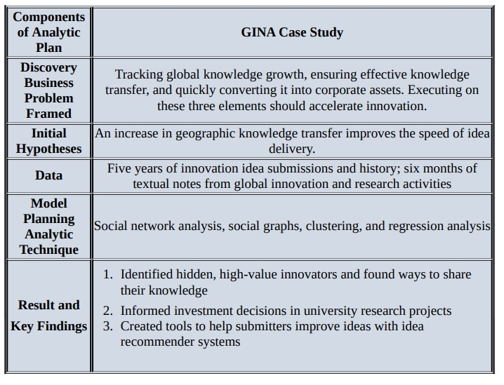

Contoh kasus